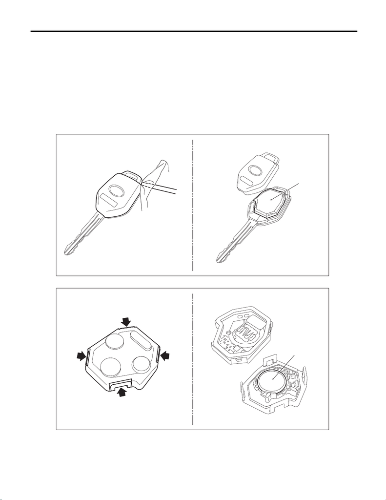

Keyless Transmitter

SECURITY AND LOCKS

25.Keyless Transmitter

A: REMOVAL

1. KEYLESS TRANSMITTER BATTERY

CAUTION:

To prevent static electricity damage to the keyless transmitter printed circuit board, touch the steel

area of building with hand to discharge static electricity carried on body or clothes before disassem-

bling the keyless transmitter.

1) Remove the keyless transmitter cover, and take out the transmitter case (A).

NOTE:

Use a flat tip screwdriver with protective tape or cloth in order not to damage the components.

2) Release the claws to open the transmitter case, then remove the battery (A).

B: INSTALLATION

1. KEYLESS TRANSMITTER BATTERY

Install each part in the reverse order of removal.

(A)

(A)

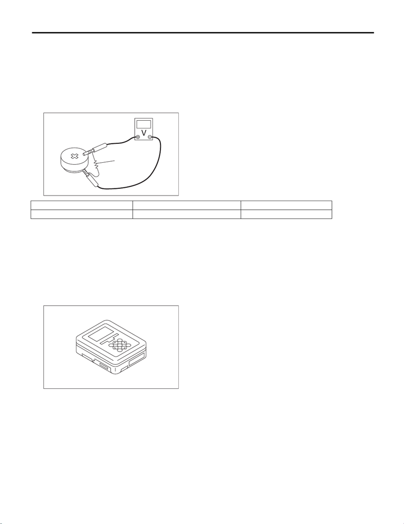

SL-83

Keyless Transmitter

SECURITY AND LOCKS

C: INSPECTION

1. KEYLESS TRANSMITTER BATTERY

1) Measure the keyless transmitter battery voltage.

Preparation tool:

Circuit tester

NOTE:

Complete the measurement within 5 seconds because the battery discharges during measurement.

2) Replace the battery if the inspection result is not within the standard value. (Use CR1620 or equivalent.)

D: REPLACEMENT

1. REGISTRATION OF KEYLESS TRANSMITTER WITH SUBARU SELECT MONITOR

NOTE:

• A maximum of four keyless transmitters can be registered for each individual vehicle.

• When replacing or adding the keyless transmitter, new registration of transmitter is necessary.

1) Prepare the Subaru Select Monitor kit. <Ref. to SL-7, SPECIAL TOOL, PREPARATION TOOL, General

Description.>

2) Prepare PC with Subaru Select Monitor installed.

3) Connect the USB cable to SDI (Subaru Diagnosis Interface) and USB port on the personal computer (ded-

icated port for the Subaru Select Monitor).

NOTE:

The dedicated port for the Subaru Select Monitor means the USB port which was used to install the Subaru

Select Monitor.

4) Connect the diagnosis cable to SDI.

(A)

Battery terminal Inspection Conditions Standard

(+) — (–) Connect resistor (A) 47 Ω 2.5 — 3.0 V

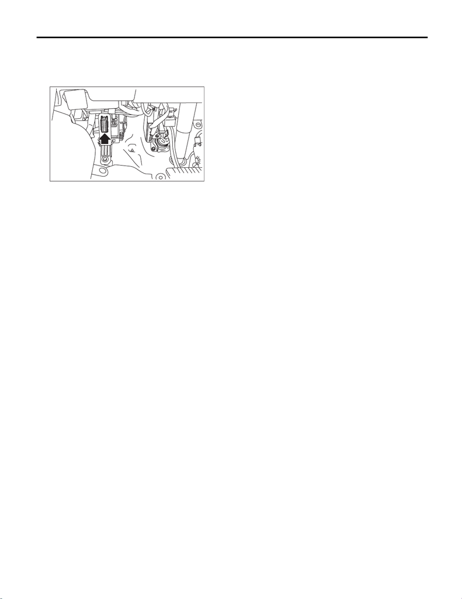

SL-84

Keyless Transmitter

SECURITY AND LOCKS

5) Connect SDI to data link connector located in the lower portion of the instrument panel (on the driver’s

side).

CAUTION:

Do not connect scan tools other than the Subaru Select Monitor.

6) Start the PC.

7) Turn the ignition switch to OFF and run the “PC application for Subaru Select Monitor”.

8) On the «Main Menu» of the Subaru Select Monitor, select {Each System Check} → {Integ. unit mode} →

{Work Support} → {Keyless ID registration}.

9) According to the directions on the screen, press the button of the transmitter to be registered in the LOCK

→ UNLOCK order. «When registration completed, external buzzer sound once.» Repeat the registration as

many times as desired.

10) Press the [Exit] button to finish the operations.

NOTE:

When attempting to register a key that has already been registered, the external buzzer sounds twice.